# Board Game Geek Exploratory Data Analysis

- Importing Packages & Loading the Dataset
- Data Cleaning
- Initial Exploration of Numeric Data
- Linear Regression Model Using Complexity & Rating Average
- Mechanics & Domains
- Data Preprocessing of Mechanics & Domains
- Random Forest Regression Models Using The Entire Dataset
- Conclusions

## Importing Packages & Loading the Dataset

```python
# Importing the libraries and packages
import pandas as pd
import numpy as np
import re
import seaborn as sns
import matplotlib.pyplot as plt
from sklearn.model_selection import train_test_split
from sklearn.linear_model import LinearRegression
from sklearn import metrics
from sklearn.metrics import mean_absolute_error, mean_squared_error, r2_score
from collections import Counter
from sklearn.ensemble import RandomForestRegressor

import warnings
warnings.filterwarnings("ignore")
```

```python
# Loading the dataset
bgg = pd.read_csv('bgg_dataset2.csv', sep = ';')
bgg
```

|  | ID | Name | Year Published | Min Players | Max Players | Play Time | Min Age | Users Rated | Rating Average | BGG Rank | Complexity Average | Owned Users | Mechanics | Domains |
| --- | --- | --- | --- | --- | --- | --- | --- | --- | --- | --- | --- | --- | --- | --- |
| 0 | 174430.0 | Gloomhaven | 2017.0 | 1 | 4 | 120 | 14 | 42055 | 8,79 | 1 | 3,86 | 68323.0 | Action Queue, Action Retrieval, Campaign / Bat... | Strategy Games, Thematic Games |
| 1 | 161936.0 | Pandemic Legacy: Season 1 | 2015.0 | 2 | 4 | 60 | 13 | 41643 | 8,61 | 2 | 2,84 | 65294.0 | Action Points, Cooperative Game, Hand Manageme... | Strategy Games, Thematic Games |
| 2 | 224517.0 | Brass: Birmingham | 2018.0 | 2 | 4 | 120 | 14 | 19217 | 8,66 | 3 | 3,91 | 28785.0 | Hand Management, Income, Loans, Market, Networ... | Strategy Games |
| 3 | 167791.0 | Terraforming Mars | 2016.0 | 1 | 5 | 120 | 12 | 64864 | 8,43 | 4 | 3,24 | 87099.0 | Card Drafting, Drafting, End Game Bonuses, Han... | Strategy Games |
| 4 | 233078.0 | Twilight Imperium: Fourth Edition | 2017.0 | 3 | 6 | 480 | 14 | 13468 | 8,70 | 5 | 4,22 | 16831.0 | Action Drafting, Area Majority / Influence, Ar... | Strategy Games, Thematic Games |
| ... | ... | ... | ... | ... | ... | ... | ... | ... | ... | ... | ... | ... | ... | ... |
| 20338 | 16398.0 | War | 0.0 | 2 | 2 | 30 | 4 | 1340 | 2,28 | 20340 | 1 | 427.0 | NaN | Children's Games |
| 20339 | 7316.0 | Bingo | 1530.0 | 2 | 99 | 60 | 5 | 2154 | 2,85 | 20341 | 1,05 | 1533.0 | Betting and Bluffing, Bingo, Pattern Recognition | Party Games |
| 20340 | 5048.0 | Candy Land | 1949.0 | 2 | 4 | 30 | 3 | 4006 | 3,18 | 20342 | 1,08 | 5788.0 | Roll / Spin and Move | Children's Games |
| 20341 | 5432.0 | Chutes and Ladders | -200.0 | 2 | 6 | 30 | 3 | 3783 | 2,86 | 20343 | 1,02 | 4400.0 | Dice Rolling, Grid Movement, Race, Roll / Spin... | Children's Games |
| 20342 | 11901.0 | Tic-Tac-Toe | -1300.0 | 2 | 2 | 1 | 4 | 3275 | 2,68 | 20344 | 1,16 | 1374.0 | Paper-and-Pencil, Pattern Building | Abstract Games, Children's Games |

20343 rows × 14 columns

```python
# Getting the general information on the dataset's features
bgg.info()
```

```
<class 'pandas.core.frame.DataFrame'>
RangeIndex: 20343 entries, 0 to 20342
Data columns (total 14 columns):
 #   Column              Non-Null Count  Dtype
---  ------              --------------  -----
 0   ID                  20327 non-null  float64
 1   Name                20343 non-null  object
 2   Year Published      20342 non-null  float64
 3   Min Players         20343 non-null  int64
 4   Max Players         20343 non-null  int64
 5   Play Time           20343 non-null  int64
 6   Min Age             20343 non-null  int64
 7   Users Rated         20343 non-null  int64
 8   Rating Average      20343 non-null  object
 9   BGG Rank            20343 non-null  int64
 10  Complexity Average  20343 non-null  object
 11  Owned Users         20320 non-null  float64
 12  Mechanics           18745 non-null  object
 13  Domains             10184 non-null  object
dtypes: float64(3), int64(6), object(5)
memory usage: 2.2+ MB
```

```python
# Looking at the size of the dataset
print(bgg.shape)
```

```
(20343, 14)
```

## Data Cleaning

```python
# Replacing the commas in Rating Average & Complexity Average columns with decimal points
bgg["Rating Average"] = bgg["Rating Average"].str.replace(',','.')
bgg["Complexity Average"] = bgg["Complexity Average"].str.replace(',','.')
```

```python
# Changing the data types of the Rating Average & Complexity Average columns to floats
bgg["Rating Average"] = pd.to_numeric(bgg["Rating Average"])
bgg["Complexity Average"] = pd.to_numeric(bgg["Complexity Average"])
```

```python
# Dropping NaN Values
bgg = bgg[bgg["Owned Users"].notna()]
bgg
```

|  | ID | Name | Year Published | Min Players | Max Players | Play Time | Min Age | Users Rated | Rating Average | BGG Rank | Complexity Average | Owned Users | Mechanics | Domains |
| --- | --- | --- | --- | --- | --- | --- | --- | --- | --- | --- | --- | --- | --- | --- |
| 0 | 174430.0 | Gloomhaven | 2017.0 | 1 | 4 | 120 | 14 | 42055 | 8.79 | 1 | 3.86 | 68323.0 | Action Queue, Action Retrieval, Campaign / Bat... | Strategy Games, Thematic Games |
| 1 | 161936.0 | Pandemic Legacy: Season 1 | 2015.0 | 2 | 4 | 60 | 13 | 41643 | 8.61 | 2 | 2.84 | 65294.0 | Action Points, Cooperative Game, Hand Manageme... | Strategy Games, Thematic Games |
| 2 | 224517.0 | Brass: Birmingham | 2018.0 | 2 | 4 | 120 | 14 | 19217 | 8.66 | 3 | 3.91 | 28785.0 | Hand Management, Income, Loans, Market, Networ... | Strategy Games |
| 3 | 167791.0 | Terraforming Mars | 2016.0 | 1 | 5 | 120 | 12 | 64864 | 8.43 | 4 | 3.24 | 87099.0 | Card Drafting, Drafting, End Game Bonuses, Han... | Strategy Games |
| 4 | 233078.0 | Twilight Imperium: Fourth Edition | 2017.0 | 3 | 6 | 480 | 14 | 13468 | 8.70 | 5 | 4.22 | 16831.0 | Action Drafting, Area Majority / Influence, Ar... | Strategy Games, Thematic Games |
| ... | ... | ... | ... | ... | ... | ... | ... | ... | ... | ... | ... | ... | ... | ... |
| 20338 | 16398.0 | War | 0.0 | 2 | 2 | 30 | 4 | 1340 | 2.28 | 20340 | 1.00 | 427.0 | NaN | Children's Games |
| 20339 | 7316.0 | Bingo | 1530.0 | 2 | 99 | 60 | 5 | 2154 | 2.85 | 20341 | 1.05 | 1533.0 | Betting and Bluffing, Bingo, Pattern Recognition | Party Games |
| 20340 | 5048.0 | Candy Land | 1949.0 | 2 | 4 | 30 | 3 | 4006 | 3.18 | 20342 | 1.08 | 5788.0 | Roll / Spin and Move | Children's Games |
| 20341 | 5432.0 | Chutes and Ladders | -200.0 | 2 | 6 | 30 | 3 | 3783 | 2.86 | 20343 | 1.02 | 4400.0 | Dice Rolling, Grid Movement, Race, Roll / Spin... | Children's Games |
| 20342 | 11901.0 | Tic-Tac-Toe | -1300.0 | 2 | 2 | 1 | 4 | 3275 | 2.68 | 20344 | 1.16 | 1374.0 | Paper-and-Pencil, Pattern Building | Abstract Games, Children's Games |

20320 rows × 14 columns

```python
# Looking at which columns have missing values
print("Columns with missing values:", bgg.columns[bgg.isnull().any()])
```

```
Columns with missing values: Index(['Mechanics', 'Domains'], dtype='object')
```

```python
# Creating new variables to find where our NaN values are
NanMech = np.where(bgg["Mechanics"].isna())
NanDom = np.where(bgg["Domains"].isna())
```

```python
# NaN values in Mechanics
bgg.iloc[NanMech]
```

|  | ID | Name | Year Published | Min Players | Max Players | Play Time | Min Age | Users Rated | Rating Average | BGG Rank | Complexity Average | Owned Users | Mechanics | Domains |
| --- | --- | --- | --- | --- | --- | --- | --- | --- | --- | --- | --- | --- | --- | --- |
| 1059 | 85256.0 | Timeline: Inventions | 2010.0 | 2 | 8 | 15 | 8 | 7257 | 6.71 | 1060 | 1.11 | 12448.0 | NaN | Family Games |
| 1150 | 113401.0 | Timeline: Events | 2011.0 | 2 | 8 | 15 | 8 | 4208 | 6.78 | 1151 | 1.10 | 7924.0 | NaN | Family Games, Party Games |
| 1216 | 131325.0 | Timeline: Diversity | 2012.0 | 2 | 8 | 15 | 8 | 3790 | 6.79 | 1217 | 1.07 | 7589.0 | NaN | Family Games, Party Games |
| 1343 | 99975.0 | Timeline: Discoveries | 2011.0 | 2 | 8 | 15 | 8 | 3506 | 6.73 | 1344 | 1.18 | 6855.0 | NaN | Family Games |
| 1397 | 145189.0 | Timeline: Music & Cinema | 2013.0 | 2 | 8 | 15 | 8 | 3090 | 6.75 | 1398 | 1.10 | 5986.0 | NaN | Family Games, Party Games |
| ... | ... | ... | ... | ... | ... | ... | ... | ... | ... | ... | ... | ... | ... | ... |
| 20308 | 5314.0 | Hangman | 1976.0 | 2 | 2 | 10 | 6 | 942 | 4.21 | 20310 | 1.11 | 1187.0 | NaN | Family Games |
| 20314 | 4143.0 | Guess Who? | 1979.0 | 2 | 2 | 20 | 6 | 4715 | 4.80 | 20316 | 1.12 | 7576.0 | NaN | Children's Games |
| 20317 | 4149.0 | Barrel of Monkeys | 1965.0 | 1 | 0 | 10 | 3 | 781 | 3.57 | 20319 | 1.06 | 701.0 | NaN | Children's Games |
| 20328 | 5895.0 | Hungry Hungry Hippos | 1978.0 | 2 | 4 | 10 | 4 | 2361 | 4.12 | 20330 | 1.05 | 2568.0 | NaN | Children's Games |
| 20338 | 16398.0 | War | 0.0 | 2 | 2 | 30 | 4 | 1340 | 2.28 | 20340 | 1.00 | 427.0 | NaN | Children's Games |

1581 rows × 14 columns

```python
# NaN values in Domains
bgg.iloc[NanDom]
```

|  | ID | Name | Year Published | Min Players | Max Players | Play Time | Min Age | Users Rated | Rating Average | BGG Rank | Complexity Average | Owned Users | Mechanics | Domains |
| --- | --- | --- | --- | --- | --- | --- | --- | --- | --- | --- | --- | --- | --- | --- |
| 663 | 293141.0 | King of Tokyo: Dark Edition | 2020.0 | 2 | 6 | 30 | 8 | 1854 | 7.89 | 664 | 1.63 | 5157.0 | Card Drafting, Dice Rolling, King of the Hill,... | NaN |
| 1011 | 177802.0 | Smash Up: It's Your Fault! | 2016.0 | 2 | 2 | 60 | 14 | 1663 | 7.53 | 1012 | 2.06 | 6347.0 | Area Majority / Influence, Hand Management, Ta... | NaN |
| 1047 | 226520.0 | Exit: The Game - The Sinister Mansion | 2018.0 | 1 | 4 | 90 | 12 | 1595 | 7.45 | 1048 | 2.61 | 3446.0 | Cooperative Game | NaN |
| 1073 | 274638.0 | Unmatched: Robin Hood vs. Bigfoot | 2019.0 | 2 | 2 | 20 | 9 | 924 | 8.24 | 1074 | 1.93 | 2665.0 | Action Points, Hand Management, Line of Sight,... | NaN |
| 1092 | 215841.0 | Exit: The Game - The Forgotten Island | 2017.0 | 1 | 4 | 90 | 12 | 2736 | 7.02 | 1093 | 2.70 | 5438.0 | Cooperative Game | NaN |
| ... | ... | ... | ... | ... | ... | ... | ... | ... | ... | ... | ... | ... | ... | ... |
| 20281 | 232895.0 | Coaster Park | 2017.0 | 2 | 4 | 60 | 8 | 304 | 3.55 | 20283 | 2.33 | 569.0 | Auction/Bidding, Card Drafting, Modular Board | NaN |
| 20286 | 276022.0 | Alien: USCSS Nostromo | 2019.0 | 2 | 7 | 40 | 14 | 263 | 1.10 | 20288 | 1.00 | 12.0 | NaN | NaN |
| 20290 | 8689.0 | Bunco | 1855.0 | 2 | 12 | 45 | 8 | 272 | 3.10 | 20292 | 1.09 | 631.0 | Dice Rolling, Paper-and-Pencil, Team-Based Game | NaN |
| 20291 | 677.0 | Would You Rather...? | 1998.0 | 3 | 8 | 20 | 12 | 678 | 4.37 | 20293 | 1.21 | 1823.0 | Voting | NaN |
| 20298 | 6283.0 | The Ungame | 1973.0 | 2 | 6 | 60 | 5 | 293 | 2.86 | 20300 | 1.21 | 487.0 | Dice Rolling, Roll / Spin and Move, Storytelling | NaN |

10136 rows × 14 columns

```python
# Filling in the NaN values with the new term "Not Mentioned"
bgg["Mechanics"] = bgg["Mechanics"].fillna("Not Mentioned")
bgg["Domains"] = bgg["Domains"].fillna("Not Mentioned")
```

```python
# Checking if any missing values remain
print("Columns with missing values:", bgg.columns[bgg.isnull().any()])
```

```
Columns with missing values: Index([], dtype='object')
```

```python
# Checking Mechanics specifically
bgg['Mechanics'].isnull().sum()
```

```
0
```

```python
# Checking Domains specifically
bgg['Domains'].isnull().sum()
```

```
0
```

```python
# Creating a function to clean the text
def Clean(Text):
    sms = re.sub('[^a-zA-Z], ,', ' ', str(Text))
    sms = sms.replace("/",",")
    sms = sms.split()
    sms = ' '.join(sms)
    return sms
bgg["Mechanics"] = bgg["Mechanics"].apply(Clean)
bgg["Domains"] = bgg["Domains"].apply(Clean)
```

```python
# Having a look at our cleaner dataset
bgg
```

|  | ID | Name | Year Published | Min Players | Max Players | Play Time | Min Age | Users Rated | Rating Average | BGG Rank | Complexity Average | Owned Users | Mechanics | Domains |
| --- | --- | --- | --- | --- | --- | --- | --- | --- | --- | --- | --- | --- | --- | --- |
| 0 | 174430.0 | Gloomhaven | 2017.0 | 1 | 4 | 120 | 14 | 42055 | 8.79 | 1 | 3.86 | 68323.0 | Action Queue, Action Retrieval, Campaign , Bat... | Strategy Games, Thematic Games |
| 1 | 161936.0 | Pandemic Legacy: Season 1 | 2015.0 | 2 | 4 | 60 | 13 | 41643 | 8.61 | 2 | 2.84 | 65294.0 | Action Points, Cooperative Game, Hand Manageme... | Strategy Games, Thematic Games |
| 2 | 224517.0 | Brass: Birmingham | 2018.0 | 2 | 4 | 120 | 14 | 19217 | 8.66 | 3 | 3.91 | 28785.0 | Hand Management, Income, Loans, Market, Networ... | Strategy Games |
| 3 | 167791.0 | Terraforming Mars | 2016.0 | 1 | 5 | 120 | 12 | 64864 | 8.43 | 4 | 3.24 | 87099.0 | Card Drafting, Drafting, End Game Bonuses, Han... | Strategy Games |
| 4 | 233078.0 | Twilight Imperium: Fourth Edition | 2017.0 | 3 | 6 | 480 | 14 | 13468 | 8.70 | 5 | 4.22 | 16831.0 | Action Drafting, Area Majority , Influence, Ar... | Strategy Games, Thematic Games |
| ... | ... | ... | ... | ... | ... | ... | ... | ... | ... | ... | ... | ... | ... | ... |
| 20338 | 16398.0 | War | 0.0 | 2 | 2 | 30 | 4 | 1340 | 2.28 | 20340 | 1.00 | 427.0 | Not Mentioned | Children's Games |
| 20339 | 7316.0 | Bingo | 1530.0 | 2 | 99 | 60 | 5 | 2154 | 2.85 | 20341 | 1.05 | 1533.0 | Betting and Bluffing, Bingo, Pattern Recognition | Party Games |
| 20340 | 5048.0 | Candy Land | 1949.0 | 2 | 4 | 30 | 3 | 4006 | 3.18 | 20342 | 1.08 | 5788.0 | Roll , Spin and Move | Children's Games |
| 20341 | 5432.0 | Chutes and Ladders | -200.0 | 2 | 6 | 30 | 3 | 3783 | 2.86 | 20343 | 1.02 | 4400.0 | Dice Rolling, Grid Movement, Race, Roll , Spin... | Children's Games |
| 20342 | 11901.0 | Tic-Tac-Toe | -1300.0 | 2 | 2 | 1 | 4 | 3275 | 2.68 | 20344 | 1.16 | 1374.0 | Paper-and-Pencil, Pattern Building | Abstract Games, Children's Games |

20320 rows × 14 columns

```python
# Creating a second dataset with non-numeric columns removed for easier use
bgg2 = bgg.drop(['ID', 'Name', 'Mechanics', 'Domains'], axis=1)
bgg2
```

|  | Year Published | Min Players | Max Players | Play Time | Min Age | Users Rated | Rating Average | BGG Rank | Complexity Average | Owned Users |
| --- | --- | --- | --- | --- | --- | --- | --- | --- | --- | --- |
| 0 | 2017.0 | 1 | 4 | 120 | 14 | 42055 | 8.79 | 1 | 3.86 | 68323.0 |
| 1 | 2015.0 | 2 | 4 | 60 | 13 | 41643 | 8.61 | 2 | 2.84 | 65294.0 |
| 2 | 2018.0 | 2 | 4 | 120 | 14 | 19217 | 8.66 | 3 | 3.91 | 28785.0 |
| 3 | 2016.0 | 1 | 5 | 120 | 12 | 64864 | 8.43 | 4 | 3.24 | 87099.0 |
| 4 | 2017.0 | 3 | 6 | 480 | 14 | 13468 | 8.70 | 5 | 4.22 | 16831.0 |
| ... | ... | ... | ... | ... | ... | ... | ... | ... | ... | ... |
| 20338 | 0.0 | 2 | 2 | 30 | 4 | 1340 | 2.28 | 20340 | 1.00 | 427.0 |
| 20339 | 1530.0 | 2 | 99 | 60 | 5 | 2154 | 2.85 | 20341 | 1.05 | 1533.0 |
| 20340 | 1949.0 | 2 | 4 | 30 | 3 | 4006 | 3.18 | 20342 | 1.08 | 5788.0 |
| 20341 | -200.0 | 2 | 6 | 30 | 3 | 3783 | 2.86 | 20343 | 1.02 | 4400.0 |
| 20342 | -1300.0 | 2 | 2 | 1 | 4 | 3275 | 2.68 | 20344 | 1.16 | 1374.0 |

20320 rows × 10 columns

```python
# Dropping a few outliers
bgg2 = bgg2[(bgg2["Max Players"]<300)]
bgg2 = bgg2[(bgg2["Play Time"]<30000)]
bgg2 = bgg2[(bgg2["Min Age"]<22)]
```

```python
# Looking at the games which had the largest number of users rated to decide whether to drop as an outlier.
# Since the games with largest number of users are some of the best-selling games ever, I have decided to not
# drop them as their features might be relevant to our analysis.
bgg.nlargest(5, ['Users Rated'])
```

|  | ID | Name | Year Published | Min Players | Max Players | Play Time | Min Age | Users Rated | Rating Average | BGG Rank | Complexity Average | Owned Users | Mechanics | Domains |
| --- | --- | --- | --- | --- | --- | --- | --- | --- | --- | --- | --- | --- | --- | --- |
| 98 | 30549.0 | Pandemic | 2008.0 | 2 | 4 | 45 | 8 | 102214 | 7.61 | 99 | 2.41 | 155312.0 | Action Points, Cooperative Game, Hand Manageme... | Family Games, Strategy Games |
| 177 | 822.0 | Carcassonne | 2000.0 | 2 | 5 | 45 | 7 | 101853 | 7.42 | 178 | 1.91 | 149337.0 | Area Majority , Influence, Map Addition, Tile ... | Family Games |
| 394 | 13.0 | Catan | 1995.0 | 3 | 4 | 120 | 10 | 101510 | 7.15 | 395 | 2.32 | 154531.0 | Dice Rolling, Hexagon Grid, Income, Modular Bo... | Family Games, Strategy Games |
| 60 | 68448.0 | 7 Wonders | 2010.0 | 2 | 7 | 30 | 10 | 84371 | 7.75 | 61 | 2.33 | 112410.0 | Card Drafting, Drafting, Hand Management, Set ... | Family Games, Strategy Games |
| 97 | 36218.0 | Dominion | 2008.0 | 2 | 4 | 30 | 13 | 78089 | 7.62 | 98 | 2.36 | 101839.0 | Deck Bag and Pool Building, Delayed Purchase, ... | Strategy Games |

## Initial Exploration of Numeric Data

```
<function matplotlib.pyplot.show(close=None, block=None)>
```

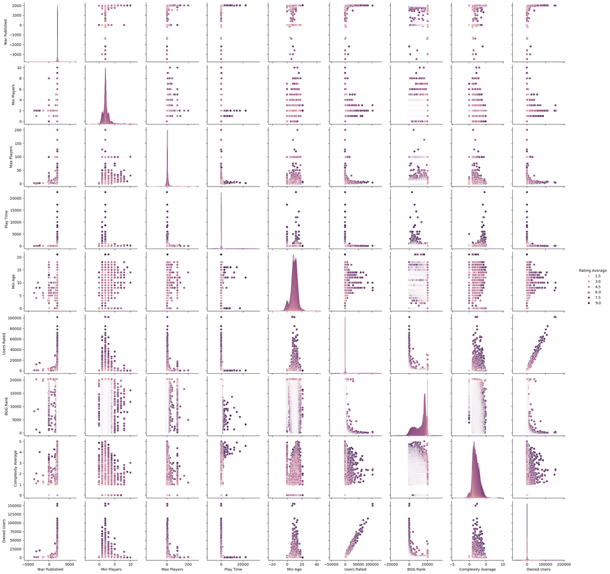

```python
# Using a pairplot to look at all of the columns plotted against each other for an initial impression
sns.pairplot(bgg2, hue = 'Rating Average')
plt.show
```

```
<function matplotlib.pyplot.show(close=None, block=None)>
```

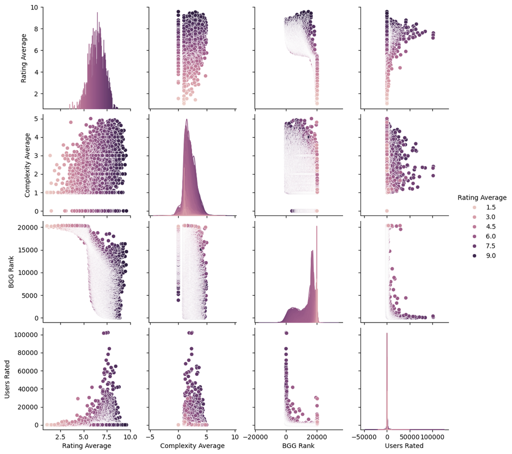

```python
# Smaller pairplot to look at how Rating Average may be affected by other related columns
sns.pairplot(bgg2, hue = 'Rating Average', vars= ['Rating Average', 'Complexity Average', 'BGG Rank', 'Users Rated'])
plt.show
```

```
<function matplotlib.pyplot.show(close=None, block=None)>
```

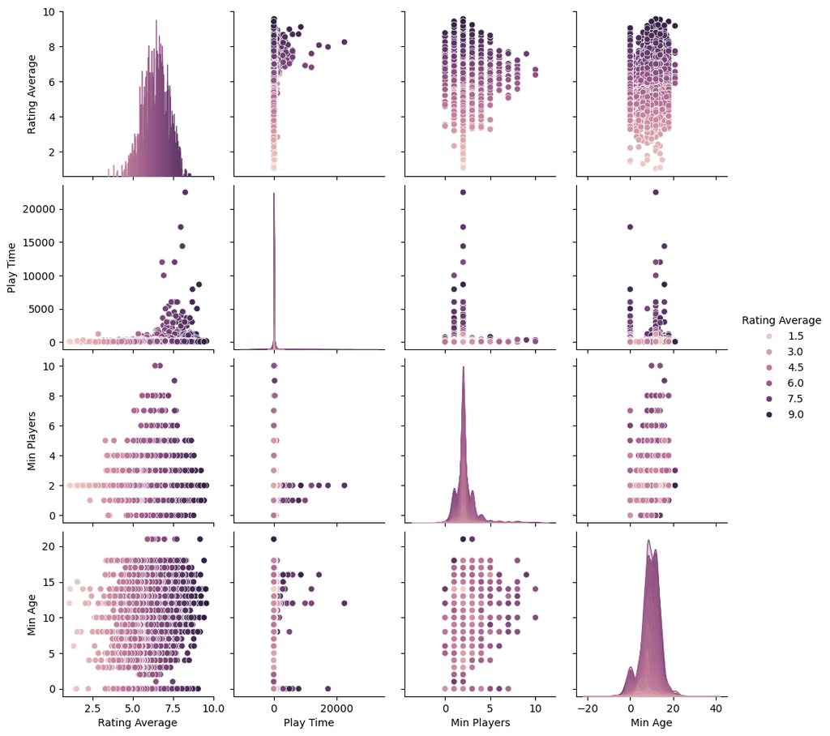

```python
# Smaller pairplot to look at how Rating Average may be affected by other related columns
sns.pairplot(bgg2, hue = 'Rating Average', vars= ['Rating Average','Play Time', 'Min Players', 'Min Age'])
plt.show
```

```
<function matplotlib.pyplot.show(close=None, block=None)>
```

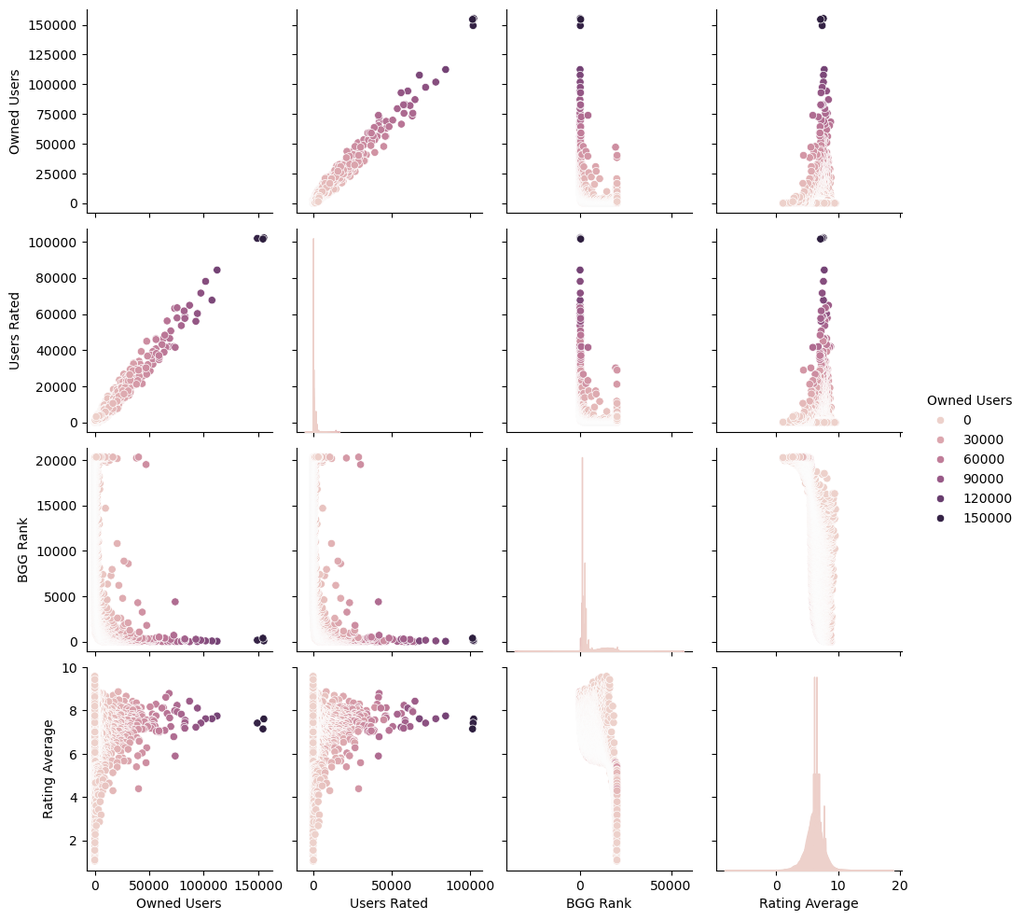

```python
# Smaller pairplot to look at how Owned Users may be affected by other related columns
sns.pairplot(bgg2, hue = 'Owned Users', vars= ['Owned Users', 'Users Rated', 'BGG Rank', 'Rating Average'])
plt.show
```

```
<function matplotlib.pyplot.show(close=None, block=None)>
```

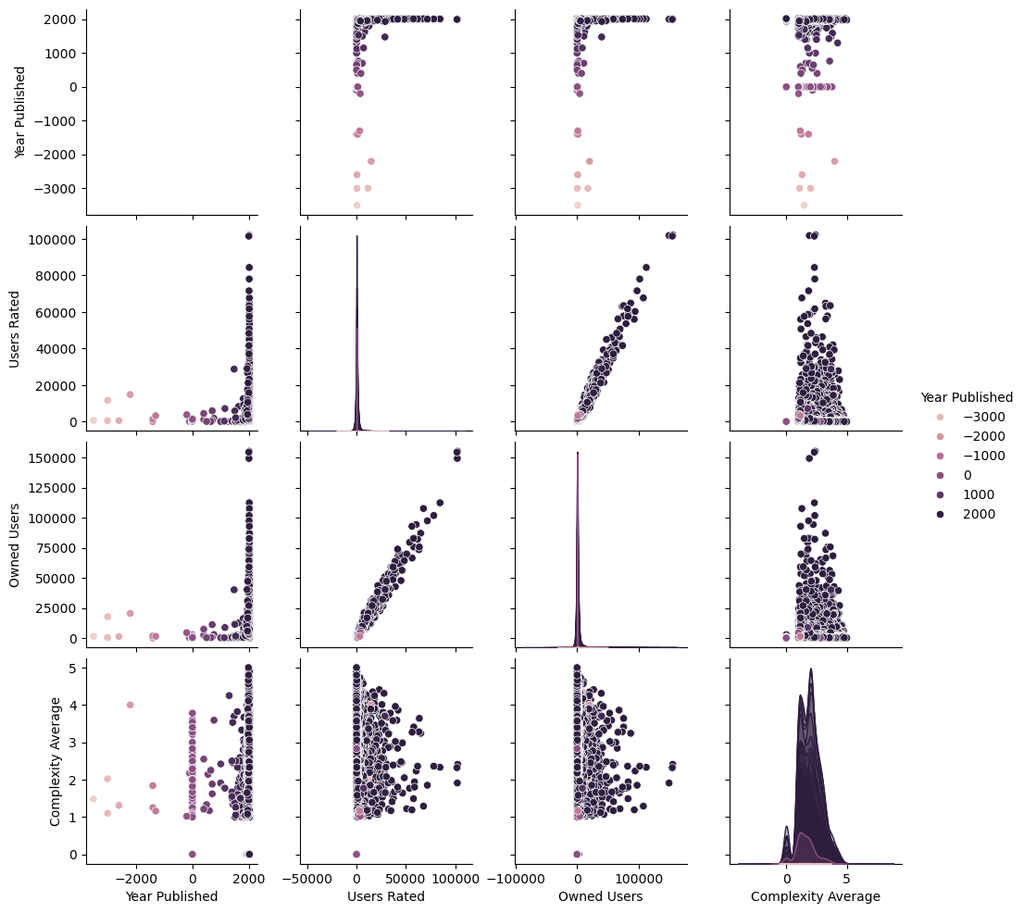

```python
# Smaller pairplot to look at how Year Published may be affected by other related columns
sns.pairplot(bgg2, hue = "Year Published", vars= ['Year Published', 'Users Rated', 'Owned Users', 'Complexity Average'])
plt.show
```

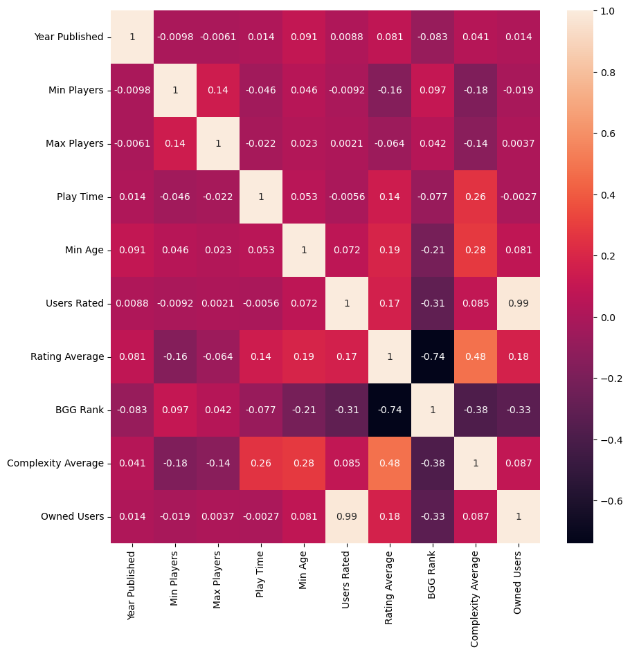

```python
# Heatmap with a correlation matrix to understand which features may correlate with each other.
corrmat= bgg2.corr()
plt.figure(figsize=(10,10))
sns.heatmap(corrmat, cbar=True, annot=True)
```

> Also, the BGG Rank and Rating Average have a strong, negative correlation. This makes sense when looking at our earlier plots where as the Rating Average increases our BGG Rank will decrease as it trends towards a number 1 rank.

> Owned Users and Users Rated have a strong correlation since typically people who purchase a game are more likely to take the time to review it. In addition, Complexity Average has a minor, positive correlation with Play Time and Min Age as games that tend to go for longer play times and are for older players will most likely have a higher levell of complexity to their game designs.

```
<function matplotlib.pyplot.show(close=None, block=None)>
```

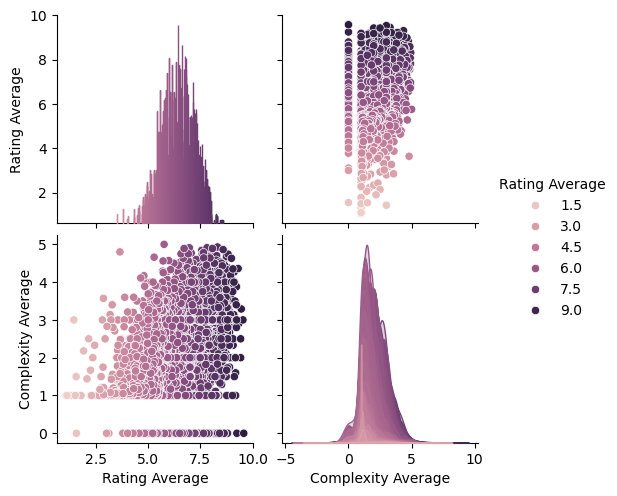

```python
# Taking another, closer look at the pairplot for Rating Average & Complexity Average alone
sns.pairplot(bgg2, hue = 'Rating Average', vars= ['Rating Average', 'Complexity Average'])
plt.show
```

## Linear Regression Model Using Complexity & Rating Average

```python
# Setting up the x and y variables for a linear regression model on how accurately Complexity Average can be
#  used to predict Raing Average
X = bgg2['Complexity Average'].values.reshape(-1,1)
y = bgg2['Rating Average'].values.reshape(-1,1)
```

```python
# Setting up the train-test-split for the model
X_train, X_test, y_train, y_test = train_test_split(X, y, test_size=0.2, random_state=0)
```

```python
# Initializing the model
regressor = LinearRegression()

# Training the algorithm
regressor.fit(X_train, y_train)
```

```
LinearRegression()
```

```python
#To retrieve the intercept:
print(regressor.intercept_)

#For retrieving the slope:
print(regressor.coef_)
```

```
[5.35526388]
[[0.52752129]]
```

```python
# Creating the prediction for our y-values
y_pred = regressor.predict(X_test)
```

```python
# Having a look at the actual vs predicted results in its own dataframe
df = pd.DataFrame({'Actual': y_test.flatten(), 'Predicted': y_pred.flatten()})
df
```

|  | Actual | Predicted |
| --- | --- | --- |
| 0 | 6.02 | 6.062142 |
| 1 | 7.08 | 6.637141 |
| 2 | 7.92 | 6.584388 |
| 3 | 6.53 | 5.355264 |
| 4 | 6.77 | 6.779571 |
| ... | ... | ... |
| 4058 | 6.67 | 6.236224 |
| 4059 | 4.87 | 7.465349 |
| 4060 | 5.18 | 6.621315 |
| 4061 | 5.90 | 6.130720 |
| 4062 | 6.16 | 6.056867 |

4063 rows × 2 columns

```python
# Looking at the metrics values on our model to see its accuracy. A good model will have errors trending
# closer to 0 and an R^2 score trending closer to 1

print('Mean Absolute Error:', metrics.mean_absolute_error(y_test, y_pred))
print('Mean Squared Error:', metrics.mean_squared_error(y_test, y_pred))
print('Root Mean Squared Error:', np.sqrt(metrics.mean_squared_error(y_test, y_pred)))
print('R^2 Score:', metrics.r2_score(y_test, y_pred))
```

```
Mean Absolute Error: 0.6271243481764985
Mean Squared Error: 0.6601674404295852
Root Mean Squared Error: 0.8125068863890232
R^2 Score: 0.24410413791119123
```

> All of the error scores are relatively high and our R_squared value is realtively low. We want values closer to 0.0 for our errors and closer to 1.0 for our coefficient of determination. This means that we can determine that our model is perhaps not too accurate, but not wildly inaccurate either. This makes sense since complexity average and rating average have some correlation, but are not enough to determine a solid predictability on how to aim for a specific rating average score based solely off of the complexity level of a game. It seems that our model can explain about 24% of the data's variance, a rather small amount.

## Mechanics & Domains

> We will now take a closer look at the Mechanics and Domains columns from our cleaned dataframe to explore their insights and to use them in conjunction with our other columns within a random forest regression model to observe how they may influence predictions on Rating Average.

> The following functions were taken from Karnika Kapoor's Board Game Analysis notebook on Kaggle, and used to extract the entries within the Mechanics and Domains columns for further analysis.

> https://www.kaggle.com/code/karnikakapoor/board-games-analysis#DATA-PREPROCESSING

```python
# Code to get Corpus
def Get_Corpus(bla):
    corpus= []
    for i in bla:
        item = i.split(",")
        corpus += item
    return corpus

# Code to delete extra space
def space_eleminator(list):
    vals=[]
    for i in list:
        m = i.lstrip()
        vals.append(m)
    return vals

Mechanics_corpus = space_eleminator(Get_Corpus(bgg["Mechanics"]))
Domains_corpus = space_eleminator(Get_Corpus(bgg["Domains"]))
```

```python
# Creating a count dictionary for items in Mechanics
Mech_dic = Counter(Mechanics_corpus)

# Exploring the occurence of Mechanincs
Item_M = list(Mech_dic.keys())
Freq_M = list(Mech_dic.values())

print("Number of unique items in Mechanics:", len(Mech_dic))
print("Most frequently used Mechanics appeared:", max(Freq_M), "times")
print("Least frequently used Mechanics appeared:", min(Freq_M), "time")

print("Ten most frequently used Mechanics: \n")
Mech_dic.most_common(10)
```

```
Number of unique items in Mechanics: 195
Most frequently used Mechanics appeared: 5671 times
Least frequently used Mechanics appeared: 1 time
Ten most frequently used Mechanics:
```

```
[('Dice Rolling', 5671),
 ('Hand Management', 4149),
 ('Set Collection', 2730),
 ('Variable Player Powers', 2533),
 ('Hexagon Grid', 2252),
 ('Simulation', 1943),
 ('Card Drafting', 1730),
 ('Tile Placement', 1692),
 ('Modular Board', 1623),
 ('Not Mentioned', 1581)]
```

```python
print("Ten least frequently used Mechanics: \n")
Mech_dic.most_common()[:-10-1:-1]
```

```
Ten least frequently used Mechanics:
```

```
[('Auction: English', 1),
 ('Auction: Dexterity', 3),
 ('Auction: Dutch Priority', 3),
 ('Selection Order Bid', 3),
 ('Passed Action Token', 4),
 ('Order Counters', 5),
 ('Hot Potato', 6),
 ('Induction', 6),
 ('Different Dice Movement', 6),
 ('Auction: Once Around', 7)]
```

```python
# Creating a count dictionary for items in Domains
Dom_dic = Counter(Domains_corpus)

# Exploring the occurence of Domains
Item_D = list(Dom_dic.keys())
Freq_D = list(Dom_dic.values())

print("Number of unique items in Domains:", len(Dom_dic))
print("Most Common Domain:", max(Freq_D), "times")
print("Least Common Domain:", min(Freq_D), "times")
print("List of Domains: \n")
Dom_dic.most_common()
```

```
Number of unique items in Domains: 9
Most Common Domain: 10136 times
Least Common Domain: 297 times
List of Domains:
```

```
[('Not Mentioned', 10136),
 ('Wargames', 3316),
 ('Strategy Games', 2205),
 ('Family Games', 2173),
 ('Thematic Games', 1174),
 ('Abstract Games', 1070),
 ("Children's Games", 849),
 ('Party Games', 605),
 ('Customizable Games', 297)]
```

## Data Preprocessing of Mechanics & Domains

```python
# Using One Hot Encoding to prepare data for a random forest regression model.

# Creating dummy variables for Mechanics
Mech_df = bgg["Mechanics"].str.get_dummies(",")

# To avoid dummy variable trap
Mech_df = Mech_df.drop('Not Mentioned', axis= 1)

# Creating dummy variables for Domains
Dom_df = bgg["Domains"].str.get_dummies(",")

# To avoid dummy variable trap
Dom_df = Dom_df.drop('Not Mentioned', axis= 1)
```

```python
# Concatenating our One Hot Encoded dataframes to our earlier dataframe for use in the model
bgg_rf = pd.concat([bgg2, Mech_df, Dom_df], axis=1)
```

```python
# Dropping NaN values which have occured as a result of the One Hot Encoding
bgg_rf.dropna(inplace=True)
bgg_rf
```

|  | Year Published | Min Players | Max Players | Play Time | Min Age | Users Rated | Rating Average | BGG Rank | Complexity Average | Owned Users | ... | Thematic Games | Wargames | Abstract Games | Children's Games | Customizable Games | Family Games | Party Games | Strategy Games | Thematic Games | Wargames |
| --- | --- | --- | --- | --- | --- | --- | --- | --- | --- | --- | --- | --- | --- | --- | --- | --- | --- | --- | --- | --- | --- |
| 0 | 2017.0 | 1.0 | 4.0 | 120.0 | 14.0 | 42055.0 | 8.79 | 1.0 | 3.86 | 68323.0 | ... | 1 | 0 | 0 | 0 | 0 | 0 | 0 | 1 | 0 | 0 |
| 1 | 2015.0 | 2.0 | 4.0 | 60.0 | 13.0 | 41643.0 | 8.61 | 2.0 | 2.84 | 65294.0 | ... | 1 | 0 | 0 | 0 | 0 | 0 | 0 | 1 | 0 | 0 |
| 2 | 2018.0 | 2.0 | 4.0 | 120.0 | 14.0 | 19217.0 | 8.66 | 3.0 | 3.91 | 28785.0 | ... | 0 | 0 | 0 | 0 | 0 | 0 | 0 | 1 | 0 | 0 |
| 3 | 2016.0 | 1.0 | 5.0 | 120.0 | 12.0 | 64864.0 | 8.43 | 4.0 | 3.24 | 87099.0 | ... | 0 | 0 | 0 | 0 | 0 | 0 | 0 | 1 | 0 | 0 |
| 4 | 2017.0 | 3.0 | 6.0 | 480.0 | 14.0 | 13468.0 | 8.70 | 5.0 | 4.22 | 16831.0 | ... | 1 | 0 | 0 | 0 | 0 | 0 | 0 | 1 | 0 | 0 |
| ... | ... | ... | ... | ... | ... | ... | ... | ... | ... | ... | ... | ... | ... | ... | ... | ... | ... | ... | ... | ... | ... |
| 20338 | 0.0 | 2.0 | 2.0 | 30.0 | 4.0 | 1340.0 | 2.28 | 20340.0 | 1.00 | 427.0 | ... | 0 | 0 | 0 | 1 | 0 | 0 | 0 | 0 | 0 | 0 |
| 20339 | 1530.0 | 2.0 | 99.0 | 60.0 | 5.0 | 2154.0 | 2.85 | 20341.0 | 1.05 | 1533.0 | ... | 0 | 0 | 0 | 0 | 0 | 0 | 1 | 0 | 0 | 0 |
| 20340 | 1949.0 | 2.0 | 4.0 | 30.0 | 3.0 | 4006.0 | 3.18 | 20342.0 | 1.08 | 5788.0 | ... | 0 | 0 | 0 | 1 | 0 | 0 | 0 | 0 | 0 | 0 |
| 20341 | -200.0 | 2.0 | 6.0 | 30.0 | 3.0 | 3783.0 | 2.86 | 20343.0 | 1.02 | 4400.0 | ... | 0 | 0 | 0 | 1 | 0 | 0 | 0 | 0 | 0 | 0 |
| 20342 | -1300.0 | 2.0 | 2.0 | 1.0 | 4.0 | 3275.0 | 2.68 | 20344.0 | 1.16 | 1374.0 | ... | 0 | 0 | 1 | 0 | 0 | 0 | 0 | 0 | 0 | 0 |

20314 rows × 355 columns

## Random Forest Regression Models Using The Entire Dataset

```python
# Assigning the features as X and trarget as y
X= bgg_rf.drop(["Rating Average"],axis =1)
y= bgg_rf["Rating Average"]

# Setting up our train-test-split
X_train, X_test, y_train, y_test = train_test_split(X, y,test_size=0.2, random_state=11)
```

```python
# Initializing our model
rf = RandomForestRegressor(random_state=13)
```

```python
# Training the model
rf.fit(X_train, y_train)
```

```
RandomForestRegressor(random_state=13)
```

```python
# Creating our y-value predictions
y_pred = rf.predict(X_test)
```

```python
# Getting the evaluation scores for our random forest regression model.

print('Mean Absolute Error:', metrics.mean_absolute_error(y_test, y_pred))
print('Mean Squared Error:', metrics.mean_squared_error(y_test, y_pred))
print('Root Mean Squared Error:', np.sqrt(metrics.mean_squared_error(y_test, y_pred)))
print('R^2 Score:', metrics.r2_score(y_test, y_pred))
```

```
Mean Absolute Error: 0.1332994339158258
Mean Squared Error: 0.05120442473541721
Root Mean Squared Error: 0.22628394714477032
R^2 Score: 0.9416946949786457
```

> All of our scores are considerably good and close to what we would like to see in an accurate model. This, however, is a problem. Our model should NOT be this accurate based off of what we know from our earlier explorations of the data. We know that most features only have a weak or moderate correlation with the Ranking Average scores, so our model should not be scoring this well. What could be causing this?

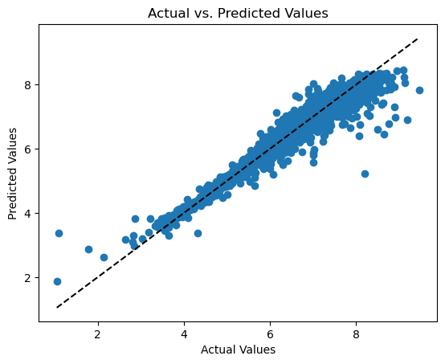

```python
# Looking at the actual vs predicted values within our model as a scatter plot. We end up with a pretty tight
# fit to the data.

plt.scatter(y_test, y_pred)
plt.xlabel("Actual Values")
plt.ylabel("Predicted Values")
plt.title("Actual vs. Predicted Values")
plt.plot([min(y_test), max(y_test)], [min(y_test), max(y_test)], 'k--')  # Diagonal line
plt.show()
```

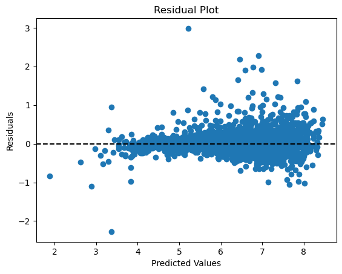

```python
# Looking at the residuals in a scatter plot. There is a little more distribution compared to the plot above, but
# we still have quite a tight fit to the data.

plt.scatter(y_pred, y_test - y_pred)
plt.xlabel("Predicted Values")
plt.ylabel("Residuals")
plt.title("Residual Plot")
plt.axhline(y=0, color='k', linestyle='--')
plt.show()
```

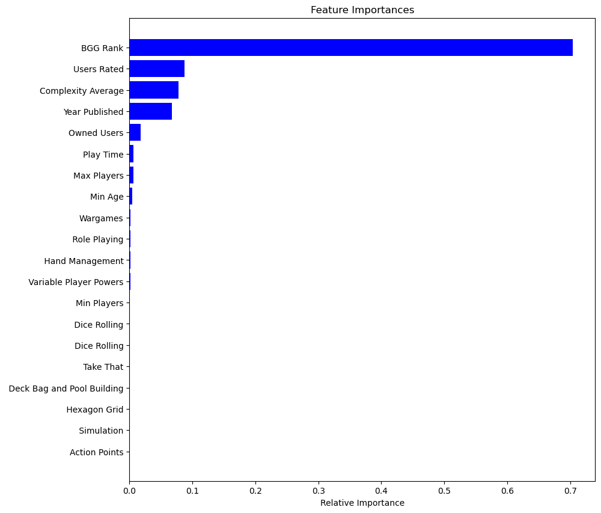

```python
# Creating a feature importance graph to see which aspects of our data are influencing the model the most.

# Setting up the features
features = X_train.columns
importances = rf.feature_importances_
indices = np.argsort(importances)

# Customized number
num_features = 20

plt.figure(figsize=(10,10))
plt.title('Feature Importances')

# Only plot the customized number of features
plt.barh(range(num_features), importances[indices[-num_features:]], color='b', align='center')
plt.yticks(range(num_features), [features[i] for i in indices[-num_features:]])
plt.xlabel('Relative Importance')
plt.show()
```

> It seems that our model is overwhelmingly being influenced by the BGG Rank column from our dataset. This now makes sense for why our evaluation scores were so good and the model able to accurately predict the Rating Average values. A games BGG Rank is a direct result of averaging the ratings that users have given it. If a game has a higher BGG Rank, then of course it will have a larger Rating Average and it becomes rather simplistic for the model to predict values based off of this information. This, however, does not help us to gain any insights on which features may lead to a higher Rating Average score BEFORE a game is released. So we must adjust our model once again to remove BGG Rank from the features and re-run everything.

```python
# Including BGG Rank in our dropped columns for the features and setting up the train-test-split
X2= bgg_rf.drop(["Rating Average", "BGG Rank"],axis =1)
y2= bgg_rf["Rating Average"]
X2_train, X2_test, y2_train, y2_test = train_test_split(X2, y2, test_size=0.2, random_state=15)
```

```python
# Initialiing the model
rf2 = RandomForestRegressor(random_state=20)
```

```python
# Training the model on our new data
rf2.fit(X2_train, y2_train)
```

```
RandomForestRegressor(random_state=20)
```

```python
# Setting up our predicted values
y2_pred = rf2.predict(X2_test)
```

```python
# Getting the evaluation scores for our random forest regression model.

print('Mean Absolute Error:', metrics.mean_absolute_error(y2_test, y2_pred))
print('Mean Squared Error:', metrics.mean_squared_error(y2_test, y2_pred))
print('Root Mean Squared Error:', np.sqrt(metrics.mean_squared_error(y2_test, y2_pred)))
print('R^2 Score:', metrics.r2_score(y2_test, y2_pred))
```

```
Mean Absolute Error: 0.4618715727295101
Mean Squared Error: 0.4047420189318237
Root Mean Squared Error: 0.6361933817101713
R^2 Score: 0.5540315219962973
```

> These values are much closer to what we would expect to see from our data. All of our metric values are much closer to the middle-of-the-road in their scores, which more accurately reflects the low to moderate correlation our features have with the Rating Average score. We can conclude that his is our most accurate model so far given the data that we have.

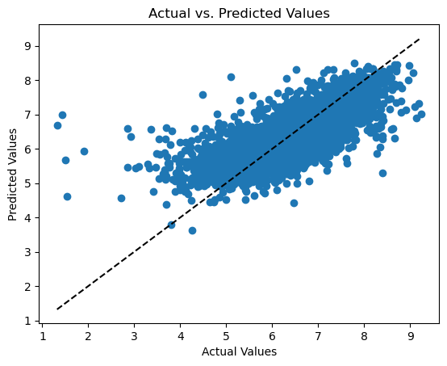

```python
# Looking at the actual vs predicted values plot. We have quite a bit more dispersion happening this time.
plt.scatter(y2_test, y2_pred)
plt.xlabel("Actual Values")
plt.ylabel("Predicted Values")
plt.title("Actual vs. Predicted Values")
plt.plot([min(y2_test), max(y2_test)], [min(y2_test), max(y2_test)], 'k--')  # Diagonal line
plt.show()
```

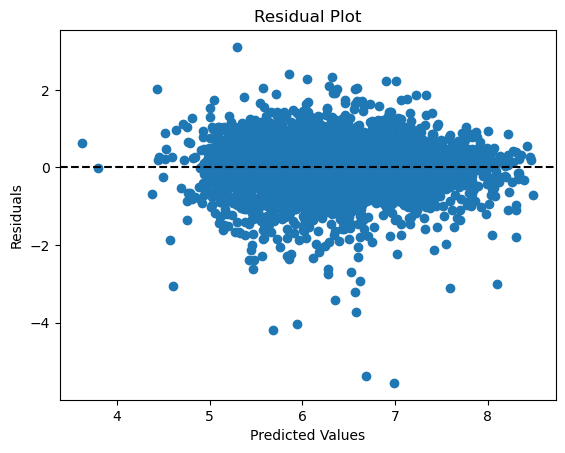

```python
# Looking at the residuals plot, once again we have more dispersion compared to our previous model.
plt.scatter(y2_pred, y2_test - y2_pred)
plt.xlabel("Predicted Values")
plt.ylabel("Residuals")
plt.title("Residual Plot")
plt.axhline(y=0, color='k', linestyle='--')
plt.show()
```

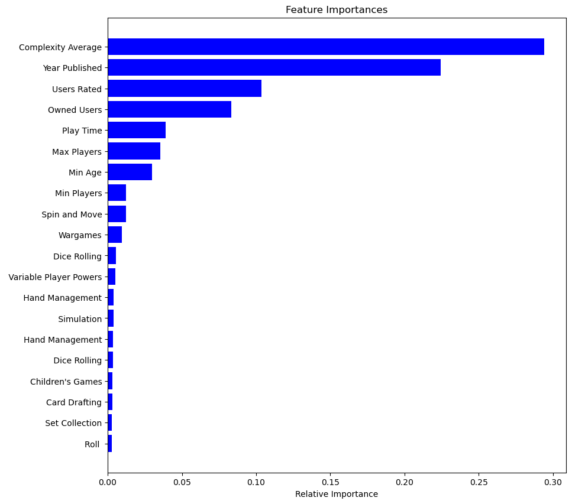

```python
# Looking at a feature importance plot to see how things have changed.

# Setting up the features
features2 = X2_train.columns
importances2 = rf2.feature_importances_
indices2 = np.argsort(importances2)

# Customized number
num_features2 = 20

plt.figure(figsize=(10,10))
plt.title('Feature Importances')

# Only plot the customized number of features
plt.barh(range(num_features2), importances2[indices2[-num_features2:]], color='b', align='center')
plt.yticks(range(num_features2), [features2[i] for i in indices2[-num_features2:]])
plt.xlabel('Relative Importance')
plt.show()
```

> Complexity Average is now the most important feature influencing our model, which matches up with what we know from our correlation matrix heatmap. Surprisingly, Year Published is the second most influential feature. This could possibly be explained by the fact that board games have been seeing a growing interest and consumer base over the last 10 - 15 years (most recent game is from 2022) and people who are invested in board games as a hobby are more likely to play newer games and to subsequently review and rate them. This leads to more recent games having some influence in our model. Following this we have the same expected features from our earlier insights; Users Rated, Owned Users, Play Time, Max Users, and Min Age all have some impact on our model.

## Conclusions

- The feature most associated with a higher Rating Average score was Complexity Average.
- However, it only has a *moderate* correlation with increasing Rating Average. Alone it is not a defining feature, but ensuring the game has some amount of complexity can lead to a higher rating average.
- The next most important features were the Year Published, the Users Rated, and the Owned Users. These had small impacts on the Rating Average, but can also be simply explained by the increasing popularity of board games as a hobby leading to more reviews and higher averages.
- Our Random Forest Regression model had a Mean Squared Error of 0.40474 and an R<sup>2</sup> Score of 0.55403 which are moderately accurate in predicting a Rating Average score based off our data and what we expected to see based off of our correlation heatmap.
- There were 195 unique Mechanics and 8 unique Domains (genres), but none of them had a significant impact on predicting Rating Average scores.
- With no particular feature heavily influencing our Rating Average, the developers have the freedom to play with its features however they want without being concerned over how it may impact the game's rating score.